# Data Visualization Workshop

Anastasia, Jamie, Zhaorong

04/18/2021

## 0.1 Read in count matrix and metadata

Use read.csv() and read.table() to read in the count matrix and metadata.

```r
metadata=read.table('metadata.tsv',stringsAsFactors = F,row.names = 1,header = T,as.is = T)

Counts=read.csv('Counts.csv',row.names = 1,header = T,as.is = T)

head(metadata)
```

```
##                Condition Timepoint
## infected_4h_1   Infected         4
## infected_4h_2   Infected         4
## infected_12h_1  Infected        12
## infected_12h_2  Infected        12
## infected_24h_1  Infected        24
## infected_24h_2  Infected        24
```

```r
head(Counts)
```

```
##          infected_4h_1 infected_4h_2 infected_12h_1 infected_12h_2 infected_24h_1 infected_24h_2 mock_4h_1 mock_4h_2
## A1BG              0.02          0.00           0.03           0.00           0.02           0.00      0.00      0.02
## A1BG-AS1          0.00          0.00           0.13           0.10           0.00           0.02      0.04      0.14
## A1CF              0.05          0.02           0.00           0.00           0.00           0.04      0.00      0.02
## A2M               0.02          0.02           0.00           0.00           0.00           0.08      0.00      0.00
## A2M-AS1           0.20          0.22           0.00           0.21           0.08           0.08      0.10      0.18
## A2ML1             0.14          0.13           0.00           0.00           0.01           0.00      0.00      0.00
##          mock_24h_1 mock_24h_2
## A1BG           0.00       0.00
## A1BG-AS1       0.00       0.02
## A1CF           0.05       0.00
## A2M            0.09       0.13
## A2M-AS1        0.18       0.13
## A2ML1          0.00       0.12
```

## 0.2 Select n top variable genes

There are more than 60,000 genes in this count matrix.

And in order to make the practice more efficient, we will use 3000 genes with largest variance.

Finding these genes is the first task in practice.

The function will take in a count matrix for calculation and an integer indicating the number of genes, return a vector of gene names being selected.

```r
top_n_variable_genes <- function(Count_matrix,n) {
  #This function returns the names of top variable features.
  variance = apply(Counts,1,var)
  variance = variance[order(variance,decreasing = T)]
  Results = names(variance[seq(1,n)])
  return(Results)
}

Top_3000_genes=top_n_variable_genes(Counts,n = 3000)
```

## 0.3 Run PCA

Principle Component Analysis is a popular tools to reduce dimensions on high dimension data.

In this case, we want to reduce the dimensions of data from 3000 to 2.

```r
CPM_calculation <- function(Counts) {
  #This function returns Counts per Million Matrix
  Results = (Counts/colSums(Counts))*10e6
  return(Results)
}

CPM=CPM_calculation(Counts[Top_3000_genes,])

LogCPM=log10(CPM+1)

PCA = prcomp((LogCPM))

summary(PCA)
```

```
## Importance of components:
##                           PC1    PC2     PC3     PC4     PC5     PC6     PC7     PC8     PC9    PC10
## Standard deviation     1.7587 0.6287 0.31676 0.26750 0.23791 0.23314 0.20224 0.19049 0.18098 0.17879
## Proportion of Variance 0.7904 0.1010 0.02564 0.01829 0.01446 0.01389 0.01045 0.00927 0.00837 0.00817
## Cumulative Proportion  0.7904 0.8914 0.91709 0.93538 0.94984 0.96373 0.97419 0.98346 0.99183 1.00000
```

Here we will use the first 2 principle components to visualize the data.

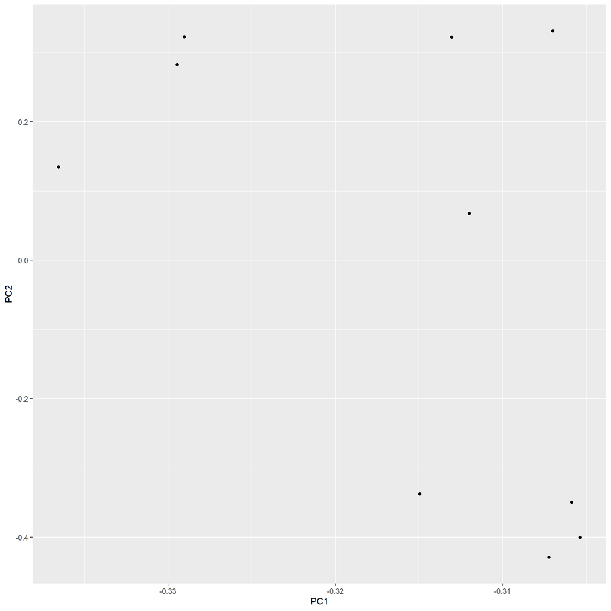

```r
PCA.figure=PCA$rotation

# In PCA object, PCA$rotation shows the principle components embeddings of the samples.

PCA_plot <- function(PCA_dimension_reduction_matrix) {
  #This function returns PCA plot
  require(ggplot2)
  Results=ggplot(data.frame(PCA_dimension_reduction_matrix),aes(x=PC1,y=PC2))+geom_point()

  return(Results)
}

PCA_plot(PCA.figure)
```

### 0.3.1 Bonus: Colouring and shaping the points on PCA plots based on sample information

The first plot is not very helpful in visualizing, we need to overlay different information on the plot so that it is more informative.

```r
PCA.figure=merge(metadata,PCA$rotation,by = 0)
#Merge the PCA embeddings with the metadata
PCA.figure$Timepoint=factor(PCA.figure$Timepoint)
# In PCA object, PCA$rotation shows the principle components embeddings of the samples.
head (PCA.figure)
```

```
##        Row.names Condition Timepoint        PC1         PC2         PC3         PC4          PC5         PC6
## 1 infected_12h_1  Infected        12 -0.3149469 -0.33750300 -0.09384274  0.49049691  0.316558050  0.32399187
## 2 infected_12h_2  Infected        12 -0.3058522 -0.34967928  0.02907303 -0.38478738  0.634623766  0.05134267
## 3 infected_24h_1  Infected        24 -0.3072273 -0.42902186  0.20371154 -0.36342928 -0.363209277 -0.10345022
## 4 infected_24h_2  Infected        24 -0.3053636 -0.40086563  0.16881530  0.31934888 -0.486822179 -0.03593920
## 5  infected_4h_1  Infected         4 -0.3365362  0.13437606 -0.53846357  0.04071172 -0.003241521  0.04361023
## 6  infected_4h_2  Infected         4 -0.3119848  0.06712145 -0.41502138 -0.01680588  0.018611036 -0.72933108
##           PC7        PC8          PC9       PC10
## 1 -0.27830549 -0.1483449  0.326037453  0.3557615
## 2  0.29779631 -0.1000636 -0.197132941 -0.3038620
## 3  0.14797400  0.4384831  0.315955399  0.3022548
## 4 -0.07869834 -0.2528959 -0.415638437 -0.3665855
## 5 -0.30335216  0.5695756 -0.007536886 -0.3983440
## 6  0.03048218 -0.3043189 -0.068400804  0.3084591
```

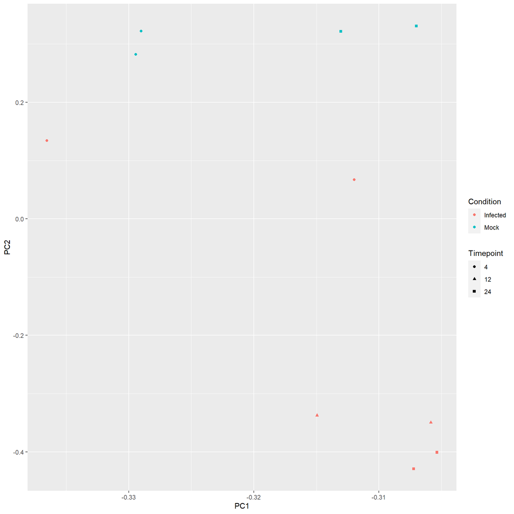

```r
PCA_plot_advance <- function(PCA_dimension_reduction_matrix_with_sample_information) {
  #This function returns PCA plot with different colors indicating Condition and different shape indicating Timepoint.
  require(ggplot2)
  Results=ggplot(data.frame(PCA_dimension_reduction_matrix_with_sample_information),aes(x=PC1,y=PC2,colour=Condition,shape=Timepoint))+geom_point()

  return(Results)
}
PCA_plot_advance(PCA.figure)
```

## 0.4 Generate a Heatmap showing relationship between samples.

In order to see the relationship between samples, correlation tests are used.

In this case we use a pacakge called ‘Pheatmap’

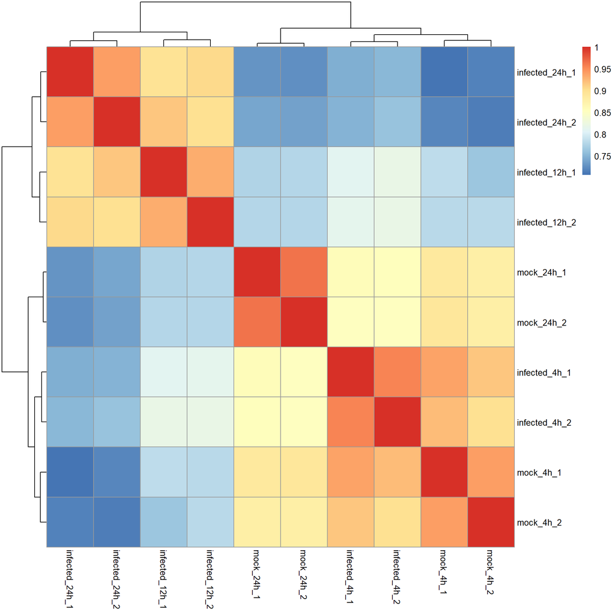

```r
correlation_test=cor((LogCPM),method = 'spearman')

library(pheatmap)

pheatmap(correlation_test)
```

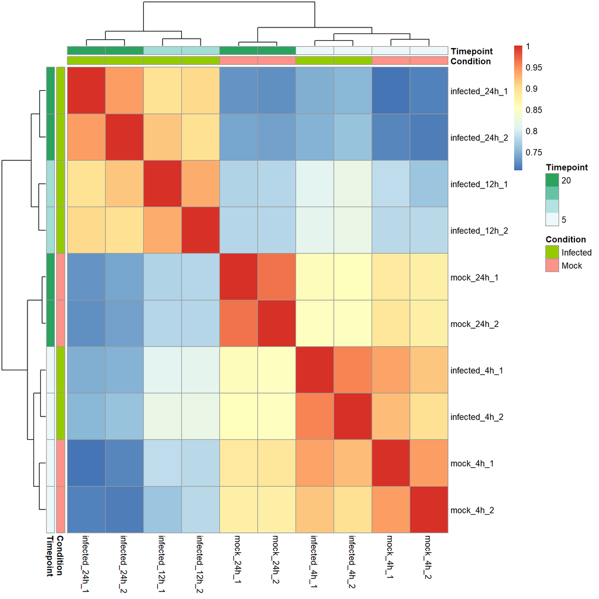

```r
#Then we add sample information to the heatmap

pheatmap(correlation_test,annotation_row = metadata,annotation_col = metadata)
```

Sometimes showing gene expression of samples using heatmap is also a good idea.

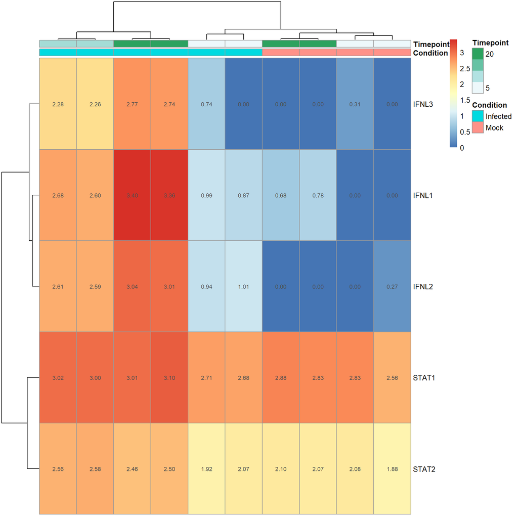

```r
pheatmap(LogCPM[c('IFNL1','IFNL2','IFNL3',
                  'STAT1','STAT2'
                  ),],annotation_col = metadata,show_colnames = F,display_numbers = T)
```

## 0.5 Volcano Plot

Volcano plot is a type of plot commonly used to display results from differential analysis.

The differential expression analysis has been done.

In the results, the log2FoldChange shows number of folds change between two condition (in this case, infected vs control).

The adjusted p value shows the significance of the changes in gene expression.

```r
Differential_expression_analysis=read.csv('Differential.expression.analysis.csv',header = T,row.names = 1)
#log2FoldChange is the log2 fold change, padj is the adjusted p value.

head(Differential_expression_analysis)
```

```
##        baseMean log2FoldChange     lfcSE       stat    pvalue      padj
## AAAS   5.486033    -0.17842959 0.4837458 0.20116110 0.9043123 0.9998221
## AAGAB 17.695173     0.04134044 0.2759675 0.06772871 0.9667026 0.9998221
## AAMDC  5.282615     0.19012253 0.4779250 1.94502542 0.3781317 0.9998221
## AAMP  32.938663    -0.03864504 0.2156028 0.04367221 0.9784006 0.9998221
## AAR2  11.385092    -0.12284388 0.3523969 0.24814273 0.8833168 0.9998221
## AARS1 18.961455     0.23013941 0.2676014 1.35736533 0.5072848 0.9998221
```

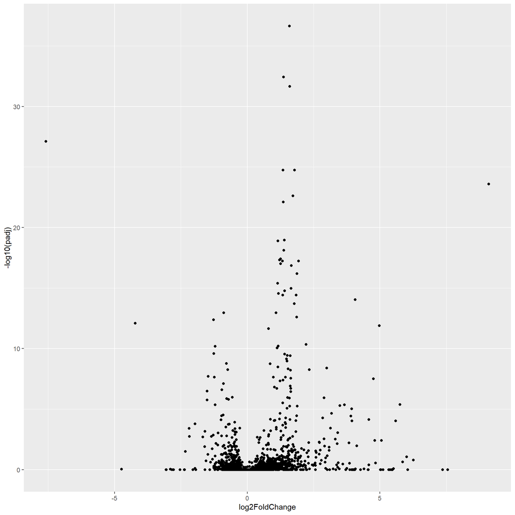

```r
volcano.plot <- function(Differential_expression_analysis) {
  require(ggplot2)

  results=ggplot(Differential_expression_analysis,aes(x=log2FoldChange,y=-log10(padj)))+geom_point()
  return(results)

}

volcano.plot(Differential_expression_analysis)
```

Again, the volcano plot without color is not quite informative, we need to set up threshold to color the differentially expressed genes.

Let us set the threshold at log2 fold change larger than 1 or smaller than -1, and adjusted p value (padj) smaller than 0.05

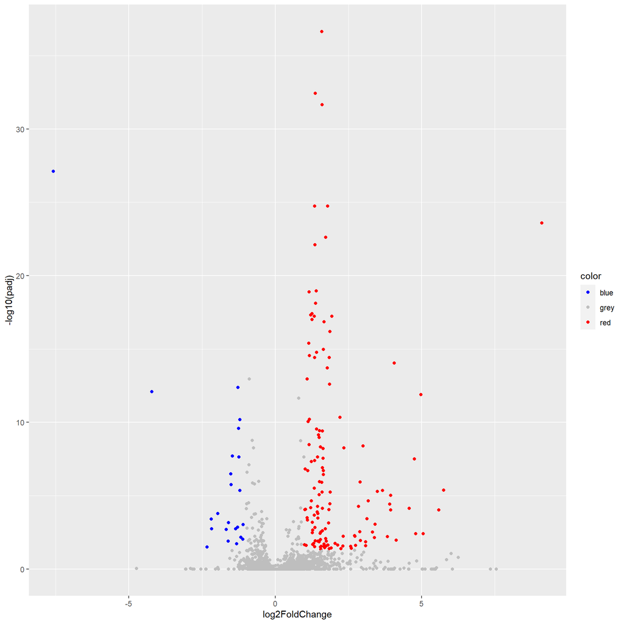

```r
volcano.plot_advance <- function(Differential_expression_analysis,lfcthreshold=1,pvalthreshold=0.05) {
  require(ggplot2)
Differential_expression_analysis$color='grey'
for (i in 1:nrow(Differential_expression_analysis)) {
if (Differential_expression_analysis$log2FoldChange[i]>1&Differential_expression_analysis$padj[i]<0.05) {
Differential_expression_analysis$color[i]='red'
}
if (Differential_expression_analysis$log2FoldChange[i]<(-1)&Differential_expression_analysis$padj[i]<0.05) {
Differential_expression_analysis$color[i]='blue'
}
}
Differential_expression_analysis$color=factor(Differential_expression_analysis$color,levels = c('blue','grey','red'))
  results=ggplot(Differential_expression_analysis,aes(x=log2FoldChange,y=-log10(padj),colour=color))+geom_point()+scale_color_manual(values = c('blue','grey','red'))
  return(results)

}

volcano.plot_advance(Differential_expression_analysis,lfcthreshold = 2,pvalthreshold = 0.05)
```